# Encontro dos Saberes FLONA do Jamari (2022)

Análise mamíferos terrestres – 2014 a 2021

Elildo Carvalho Jr - ICMBio/CENAP

2022-04-19

## Apresentação

Este relatório apresenta resultados do Programa Monitora, Subprograma Terrestre, Componente Florestal Global, Alvo Mamíferos terrestres de médio e grande porte, protocolo básico, na **Floresta Nacional do Jamari**, 2014 a 2021. O principal objetivo é subsidiar o Encontro dos Saberes que será realizado nesta unidade.

## Métodos

O protocolo básico para mamíferos utiliza o método de transecções lineares. Resumidamente, dois observadores percorrem as transecções a uma velocidade constante e registram, para cada avistamento de animais dos grupos-alvo, a espécie, o número de indivíduos e a distância perperndicular entre o primeiro indivíduo avistado e o centro da trilha. Cada UC deve ter pelo menos três transectos de 5 km e o esforço anual mínimo, combinando todos os transectos, deve ser de 150 km percorridos. A tabela 1 apresenta o esforço anual por trilha na FLONA do Jamari.

Tabela 1. Esforço de amostragem anual (em km) nas trilhas do ProgramaMonitora na FLONA do jamari, 2014-2021

| EA | nome EA | 2014 | 2015 | 2016 | 2017 | 2018 | 2019 | 2020 | 2021 |
| --- | --- | --- | --- | --- | --- | --- | --- | --- | --- |
| 1 | Fazenda | 25 | NA | 50 | 50 | NA | NA | NA | NA |
| 2 | Potosí | 25 | 45 | 45 | 50 | 50 | 50 | 40 | 50 |
| 3 | Rio Jacundá | NA | NA | 25 | 50 | 50 | 50 | NA | 50 |
| 4 | do Zé | NA | NA | NA | NA | 50 | 55 | 25 | 50 |

## Número total de encontros

A tabela 2 apresenta o número total de encontros e de indivíduos avistados por espécie. As espécies mais encontradas foram, nessa ordem: cutia, macaco-prego, macaco-aranha, soim e mico-da-cara-preta. A maioria das outras espécies foram encontradas poucas (< 10) vezes. Para as espécies que vivem em grupos, o número indivíduos pode ser maior do que o número de encontros.

É importante lembrar que só porque uma espécie foi registrada poucas vezes, não quer dizer necessariamente que ela seja rara. Por exemplo, o protocolo não funciona bem para espécies noturnas como as antas e as pacas, pois as trilhas são percorridas durante o dia, quando essas espécies estão menos ativas. Além disso, espécies que são caçadas podem ficar muito ariscas, fugindo ao menor sinal da aproximação de pessoas.

Tabela 2. Numero de registros por especie obtidos pelo protocolo básicodo Programa Monitora na FLONA do Jamari, 2014-2021

| Ordem | Familia | Especie | Nome popular | Encontros | Individuos |
| --- | --- | --- | --- | --- | --- |
| Artiodactyla | Cervidae | Mazama americana | Veado-mateiro | 8 | 9 |
| Artiodactyla | Cervidae | Mazama nemorivaga | Veado-fuboca | 17 | 17 |
| Artiodactyla | Cervidae | Mazama sp. | Veado | 5 | 5 |
| Artiodactyla | Tayassuidae | Pecari tajacu | Caititu | 19 | 38 |
| Artiodactyla | Tayassuidae | Tayassu pecari | Queixada | 13 | 66 |
| Carnivora | Felidae | Panthera onca | Onça-pintada | 3 | 3 |
| Carnivora | Felidae | Puma concolor | Onça-vermelha | 2 | 2 |
| Carnivora | Felidae | Puma yagouaroundi | Gato-mourisco | 1 | 1 |
| Carnivora | Mustelidae | Eira barbara | Irara | 6 | 7 |
| Carnivora | Procyonidae | Nasua nasua | Quati | 9 | 30 |
| Cingulata | Dasypodidae | Cabassous unicinctus | Tatu-de-rabo-mole | 1 | 1 |
| Lagomorpha | Leporidae | Sylvilagus brasiliensis | Tapeti | 1 | 1 |
| Perissodactyla | Tapiridae | Tapirus terrestris | Anta | 5 | 6 |
| Pilosa | Myrmecophagidae | Myrmecophaga tridactyla | Tamanduá-bandeira | 1 | 1 |
| Pilosa | Myrmecophagidae | Tamandua tetradactyla | Mambira | 5 | 5 |
| Primates | Atelidae | Ateles chamek | Macaco-aranha | 76 | 290 |
| Primates | Callitrichidae | Mico rondoni | Mico-da-cara-preta | 30 | 87 |
| Primates | Callitrichidae | Saguinus weddelli | Soim | 62 | 235 |
| Primates | Cebidae | Saimiri ustus | Mico-de-cheiro | 27 | 115 |
| Primates | Cebidae | Sapajus apella | Macaco-prego | 119 | 436 |
| Primates | Pitheciidae | Callicebus brunneus | Zogue-zogue | 22 | 58 |
| Primates | Pitheciidae | Pithecia irrorata | Macaco-velho | 25 | 63 |
| Rodentia | Caviidae | Hydrochoerus hydrochaeris | Capivara | 1 | 2 |
| Rodentia | Dasyproctidae | Dasyprocta fuliginosa | Cutia | 144 | 153 |
| Rodentia | Sciuridae | Sciuridae | Quatipuru | 13 | 14 |

Figura 1. Número total de encontros por espécie na FLONA do Jamari, 2014-2021. Somente espécies com mais de 5 encontros foram incluídas

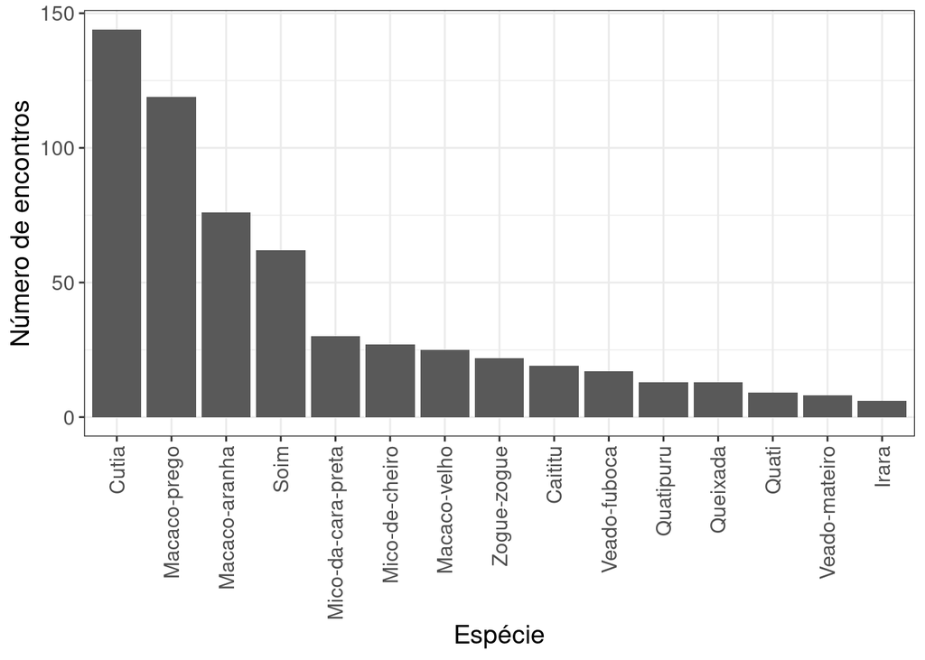

# Tendências populacionais

Somente quatro espécies apresentaram taxa de encontro anual média > 0.04 ind/km, o que equivale aproximadamente a um encontro a cada 25 km percorridos (Tabela 3): cutia, macaco-prego, macaco-aranha e soim. As Figuras 2 a 5 mostram como as taxas de avistamento variaram para estas espécies ao longo do monitoramento.

A taxa de avistamento de cutia e macaco-aranha parecem estar aumentando ao longo do tempo. Por outro lado, a taxa de avistamento do macaco-prego parece estar diminuindo levemente, e a do soim parece estar diminuindo de forma consistente. As outras especies não tiveram número de encontros suficiente para permitir uma análise de suas tendências populacionais.

Tabela 3. Taxas de encontro anuais na FLONA do Jamari

| especie | 2014 | 2015 | 2016 | 2017 | 2018 | 2019 | 2020 | 2021 | média |
| --- | --- | --- | --- | --- | --- | --- | --- | --- | --- |
| Dasyprocta fuliginosa | 0.08 | 0.20 | 0.24 | 0.14 | 0.11 | 0.10 | 0.12 | 0.28 | 0.159 |
| Sapajus apella | 0.14 | 0.04 | 0.17 | 0.15 | 0.14 | 0.15 | 0.03 | 0.14 | 0.120 |
| Ateles chamek | 0.06 | 0.11 | 0.08 | 0.07 | 0.06 | 0.08 | 0.05 | 0.15 | 0.083 |
| Saguinus weddelli | 0.06 | 0.04 | 0.08 | 0.09 | 0.07 | 0.06 | 0.06 | 0.07 | 0.067 |

Figura 2. Taxa de encontro anual para cutia na FLONA do Jamari, 2014-2021

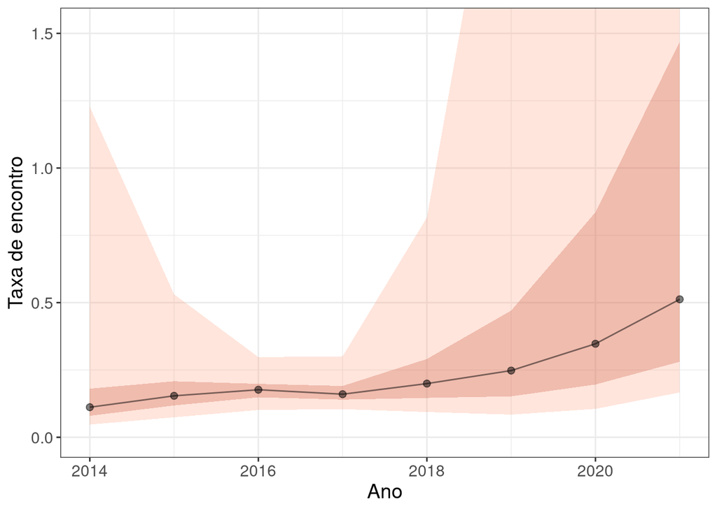

Figura 3. Taxa de encontro anual para macaco-prego na FLONA do Jamari, 2014-2021

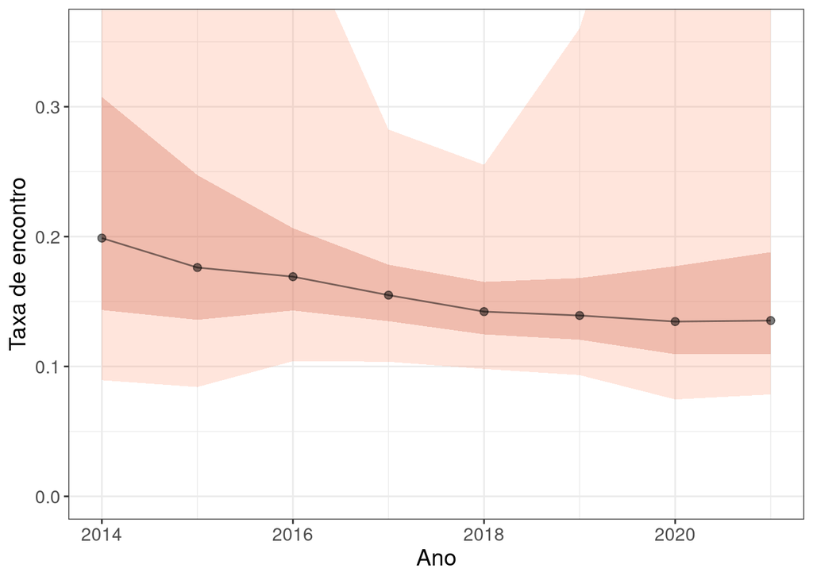

Figura 4. Taxa de encontro anual para macaco-aranha na FLONA do Jamari, 2014-2021

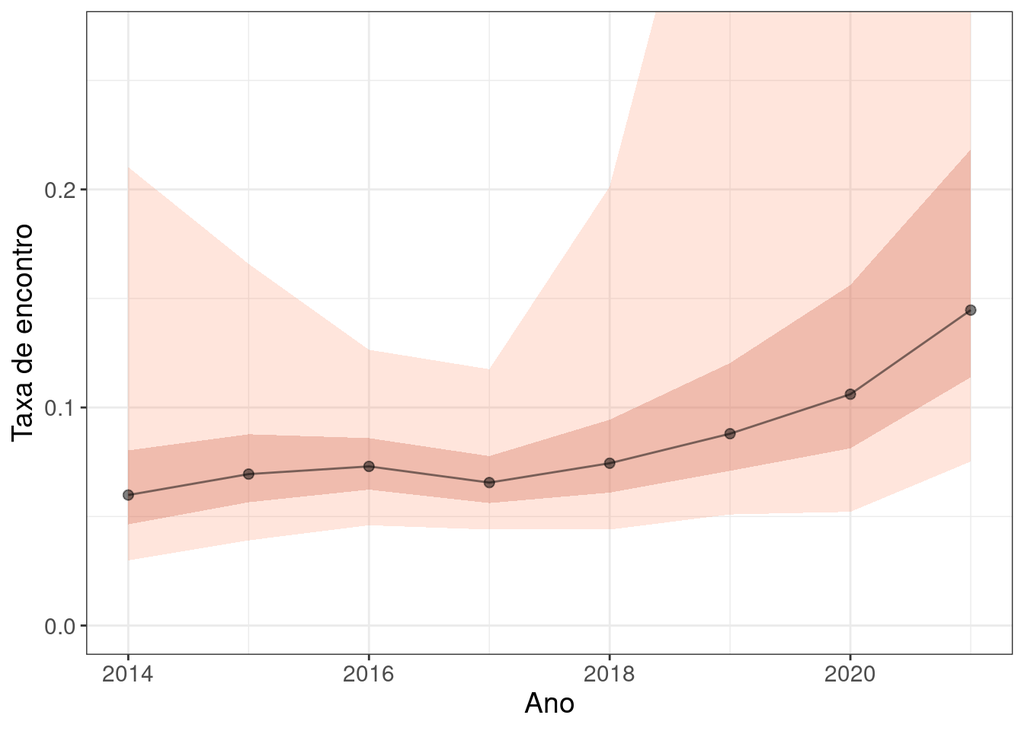

Figura 5. Taxa de encontro anual para soim na FLONA do Jamari, 2014-2021

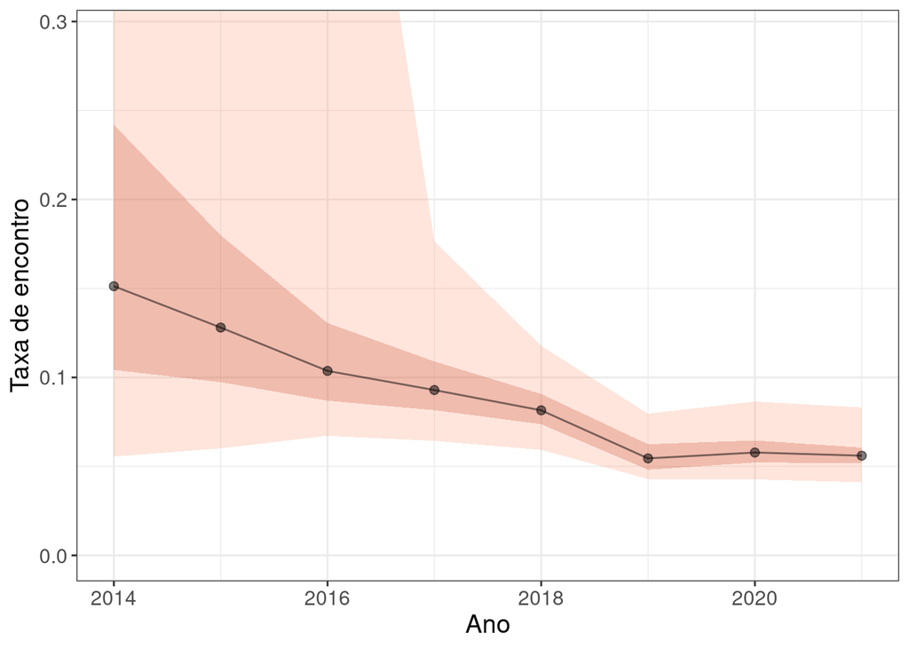

# Tendências populacionais por trilha

A análise anterior avaliou as tendências médias, agregando os dados de todas a trilhas. No entanto, também é importante avaliar o que acontece em cada trilha separadamente. As figuras 6 a 9 mostram que houve muita variação entre as trilhas, além de terem faltado dados para algumas trilhas em alguns anos.

Figura 6. Taxa de encontro anual para cutia por trilha na FLONA do Jamari, 2014-2021

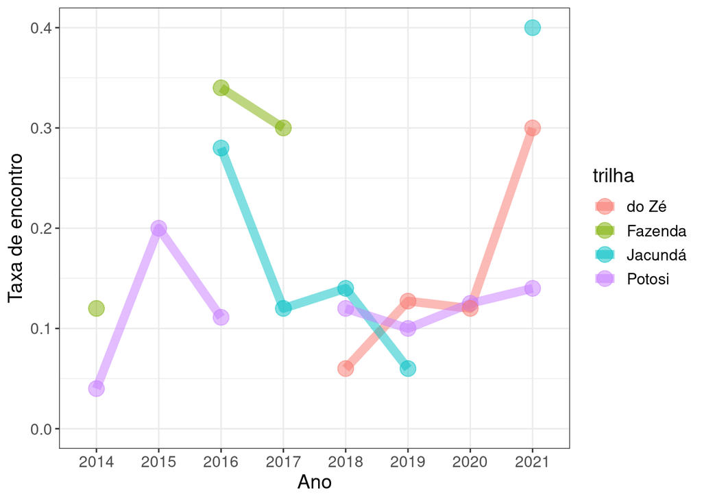

Figura 7. Taxa de encontro anual para macaco-prego por trilha na FLONA do Jamari, 2014-2021

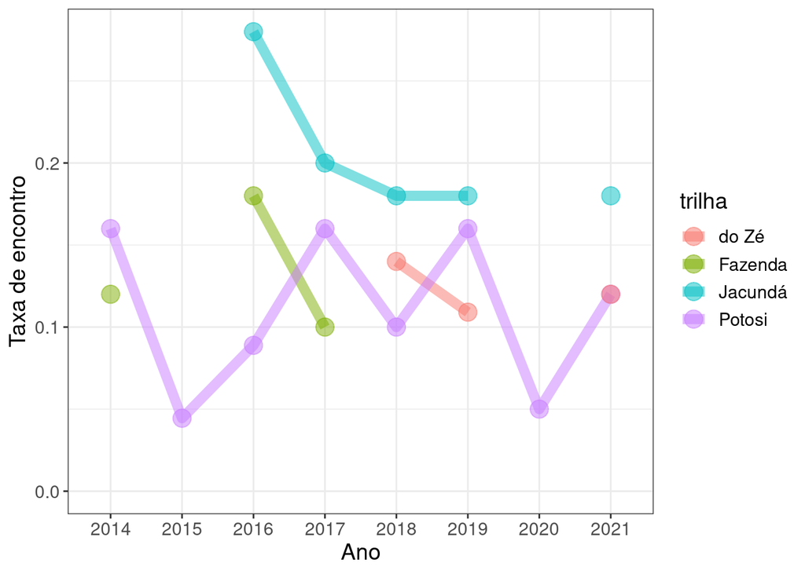

Figura 8. Taxa de encontro anual para macaco-aranha por trilha na FLONA do Jamari, 2014-2021

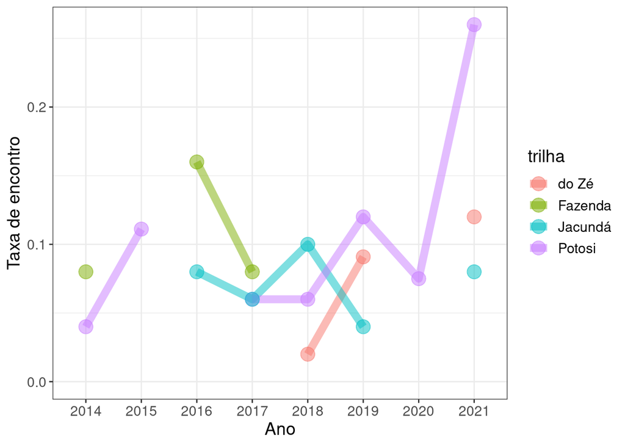

Figura 9. Taxa de encontro anual para soim por trilha na FLONA do Jamari, 2014-2021

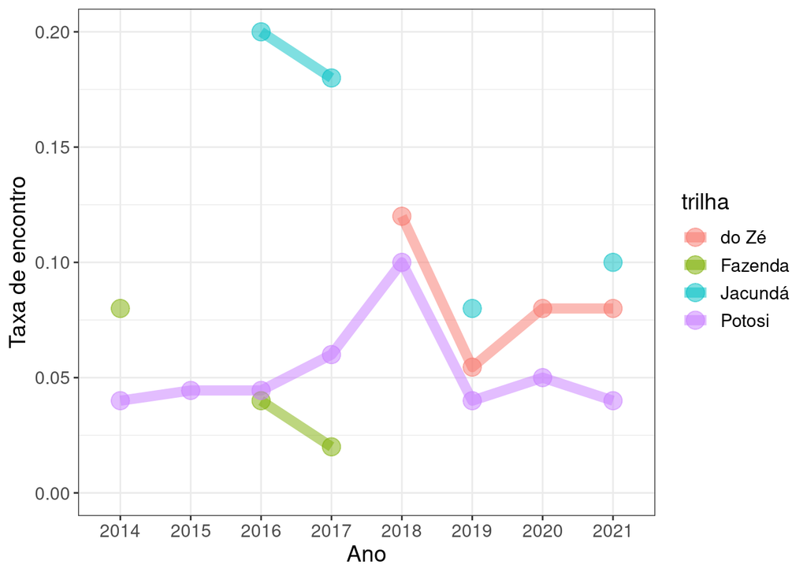

# Perguntas e reflexões

As espécies mais comuns encontradas no monitoramento foram cutia, macaco-prego, macaco-aranha, soim e mico-da-cara-preta. Isso está de acordo com a percepção da comunidade?

Como explicar a tendência de aumento na taxa de encontro de cutias e macaco aranha? E a tendência de diminuição para prego e soim? Está acontecendo alguma coisa na região que possa explicar isso?

Como explicar as variações na taxa de avistamento entre as trilhas?

Porque é importante monitorar várias trilhas ao invés de apenas uma?